# HST.953 Workshop Regression Pset4

Ryo uchimido

10/27/2017

```r
library(Hmisc)
dat <- read.csv("/Users/uchimidouryou/Documents/aline-dataset.csv")

dim(dat)
```

```
## [1] 2751   50
```

```r
dat$age.cat <- cut2(dat$age,g=4)
# Added so the file will compile.  You will need to update this variable later on.

dat$service_unit2 <- dat$service_unit=="MICU"
# Added so the file will compile.  You will need to update this variable later on.
```

### Student Question 1:

> 1. Make an appropriate plot to visual SOFA scores `sofa_first` by service unit (`service_unit`).

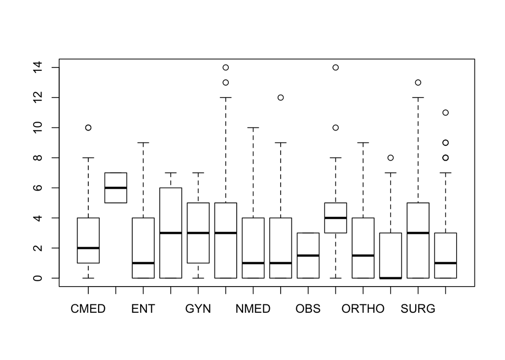

```r
plot(dat$service_unit,dat$sofa_first)
```

> b) Some of the services have small number of patients. Create a new variable called `service_unit2` with any service with less than 200 patients lumped into a new category, “Other”. Plot these new categories as you did in part a). Comment briefly about any conclusions you would draw based on the figure.

```r
summary(dat$sofa_first)
```

```
##    Min. 1st Qu.  Median    Mean 3rd Qu.    Max.
##   0.000   0.000   2.000   2.652   4.000  14.000
```

```r
summary(dat$service_unit)
```

```
##  CMED  DENT   ENT    GU   GYN   MED  NMED NSURG   OBS  OMED ORTHO PSURG
##   188     2    34    14     9  1031   357   278     2    13    52    16
##  SURG TRAUM
##   220   535
```

```r
dat$service_unit2 <- "Others"
dat$service_unit2[dat$service_unit == "MED"] <- "MED"
dat$service_unit2[dat$service_unit == "NMED"] <- "NMED"
dat$service_unit2[dat$service_unit == "NSURG"] <- "NSURG"
dat$service_unit2[dat$service_unit == "SURG"] <- "SURG"
dat$service_unit2[dat$service_unit == "TRAUM"] <- "TRAUM"
dat$service_unit2 <- as.factor(dat$service_unit2)
```

### why do we need to convert dat$service_unit2 to a factor?

```r
summary(dat$service_unit2)
```

```
##    MED   NMED  NSURG Others   SURG  TRAUM
##   1031    357    278    330    220    535
```

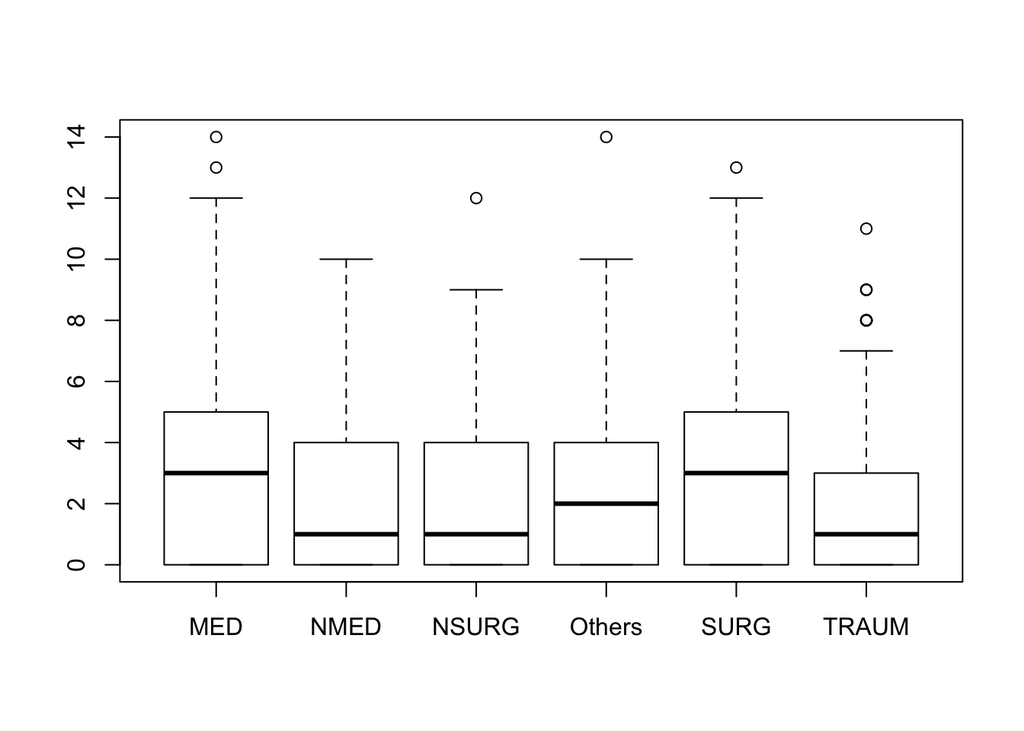

```r
plot(dat$service_unit2,dat$sofa_first)
```

### The median levels of the sofa score in MED, SURG apperears to be higher than those of NMED,NSURG and TRAUM.However, there is no statistical test.

> 3. Fit a regression with `sofa_first` as the outcome and `service_unit2` as a covariate. Pick one service unit, explain what the estimated coefficient means, include a 95% confidence interval and a p-value.

```r
library(sjPlot)
devtools::install_github("strengejacke/strengejacke")
library(sjPlot)
```

```r
sofa.serviceunit2.lm <- lm(I(dat$sofa_first) ~ I(dat$service_unit2),data=dat,na.action = na.exclude)
summary(sofa.serviceunit2.lm)
```

```
##
## Call:
## lm(formula = I(dat$sofa_first) ~ I(dat$service_unit2), data = dat,
##     na.action = na.exclude)
##
## Residuals:
##     Min      1Q  Median      3Q     Max
## -3.3545 -2.0972 -0.3545  1.7311 11.3879
##
## Coefficients:
##                            Estimate Std. Error t value Pr(>|t|)
## (Intercept)                 3.04268    0.08072  37.696  < 2e-16 ***
## I(dat$service_unit2)NMED   -0.77377    0.15916  -4.862 1.23e-06 ***
## I(dat$service_unit2)NSURG  -0.78728    0.17515  -4.495 7.25e-06 ***
## I(dat$service_unit2)Others -0.43056    0.16392  -2.627  0.00867 **
## I(dat$service_unit2)SURG    0.31187    0.19248   1.620  0.10529
## I(dat$service_unit2)TRAUM  -0.94548    0.13810  -6.846 9.30e-12 ***
## ---
## Signif. codes:  0 '***' 0.001 '**' 0.01 '*' 0.05 '.' 0.1 ' ' 1
##
## Residual standard error: 2.592 on 2745 degrees of freedom
## Multiple R-squared:  0.0278, Adjusted R-squared:  0.02603
## F-statistic:  15.7 on 5 and 2745 DF,  p-value: 2.884e-15
```

```r
confint(sofa.serviceunit2.lm)
```

```
##                                  2.5 %     97.5 %
## (Intercept)                 2.88440445  3.2009496
## I(dat$service_unit2)NMED   -1.08584969 -0.4616892
## I(dat$service_unit2)NSURG  -1.13072306 -0.4438396
## I(dat$service_unit2)Others -0.75197938 -0.1091322
## I(dat$service_unit2)SURG   -0.06554986  0.6892867
## I(dat$service_unit2)TRAUM  -1.21626577 -0.6746957
```

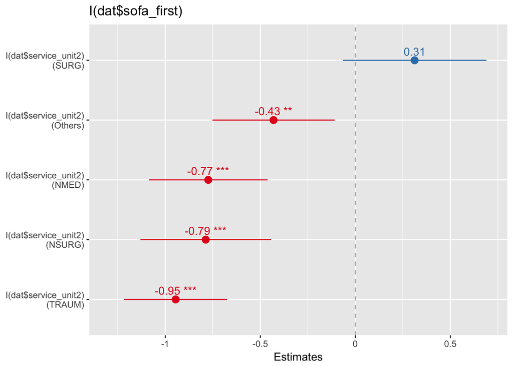

```r
sjp.lm(sofa.serviceunit2.lm, type="coef")
```

> 4. Conduct a hypothesis test to assess if the mean SOFA score is the same for all service units.

```r
anova(sofa.serviceunit2.lm)
```

```
## Analysis of Variance Table
##
## Response: I(dat$sofa_first)
##                        Df  Sum Sq Mean Sq F value    Pr(>F)
## I(dat$service_unit2)    5   527.3 105.454  15.699 2.884e-15 ***
## Residuals            2745 18438.8   6.717
## ---
## Signif. codes:  0 '***' 0.001 '**' 0.01 '*' 0.05 '.' 0.1 ' ' 1
```

```r
drop1(sofa.serviceunit2.lm, test = "F")
```

```
## Single term deletions
##
## Model:
## I(dat$sofa_first) ~ I(dat$service_unit2)
##                      Df Sum of Sq   RSS    AIC F value    Pr(>F)
## <none>                            18439 5245.8
## I(dat$service_unit2)  5    527.27 18966 5313.3  15.699 2.884e-15 ***
## ---
## Signif. codes:  0 '***' 0.001 '**' 0.01 '*' 0.05 '.' 0.1 ' ' 1
```

### From the result above, there is a significant dirrence of the mean SOFA score amomg all service units. drop1(sofa.serviceunit2.lm, test = “F”)

> 5. Add the `log(bun_first)` to your model in part c) (you do not need to consider an interaction).  
>    Test if the coefficient for `log(bun_first)` is zero. Interpret this new effect.

```r
sofa.serviceunit2.logbun.lm <- lm(I(dat$sofa_first) ~ I(dat$service_unit2) + log(bun_first), data = dat)
summary(sofa.serviceunit2.logbun.lm)
```

```
##
## Call:
## lm(formula = I(dat$sofa_first) ~ I(dat$service_unit2) + log(bun_first),
##     data = dat)
##
## Residuals:
##     Min      1Q  Median      3Q     Max
## -4.1371 -2.1130 -0.5052  1.6391 10.8913
##
## Coefficients:
##                            Estimate Std. Error t value Pr(>|t|)
## (Intercept)                 0.59703    0.28519   2.093  0.03641 *
## I(dat$service_unit2)NMED   -0.75042    0.16440  -4.564 5.26e-06 ***
## I(dat$service_unit2)NSURG  -0.80601    0.18178  -4.434 9.67e-06 ***
## I(dat$service_unit2)Others -0.27091    0.18942  -1.430  0.15279
## I(dat$service_unit2)SURG    0.65493    0.20499   3.195  0.00142 **
## I(dat$service_unit2)TRAUM  -0.82606    0.14292  -5.780 8.45e-09 ***
## log(bun_first)              0.88745    0.09258   9.585  < 2e-16 ***
## ---
## Signif. codes:  0 '***' 0.001 '**' 0.01 '*' 0.05 '.' 0.1 ' ' 1
##
## Residual standard error: 2.54 on 2396 degrees of freedom
##   (348 observations deleted due to missingness)
## Multiple R-squared:  0.07787,    Adjusted R-squared:  0.07556
## F-statistic: 33.72 on 6 and 2396 DF,  p-value: < 2.2e-16
```

```r
drop1(sofa.serviceunit2.logbun.lm,test = "F")
```

```
## Single term deletions
##
## Model:
## I(dat$sofa_first) ~ I(dat$service_unit2) + log(bun_first)
##                      Df Sum of Sq   RSS    AIC F value    Pr(>F)
## <none>                            15460 4487.3
## I(dat$service_unit2)  5    512.28 15972 4555.6  15.878 2.042e-15 ***
## log(bun_first)        1    592.85 16053 4575.7  91.879 < 2.2e-16 ***
## ---
## Signif. codes:  0 '***' 0.001 '**' 0.01 '*' 0.05 '.' 0.1 ' ' 1
```

## the null hypothesis that thecoefficient for `log(bun_first)` is zero is rejected.Bun at ICU admission DAY1 is significantly related to SOFA score at the same day.

### Student Question 2:

> 1. Fit a logistic regression between `aline_flg` and in hospital death (`hosp_exp_flg`). Interpret and briefly explain the results of this model.

```r
aline.glm2 <- glm(hosp_exp_flg ~ aline_flg, data=dat, family = "binomial")
summary(aline.glm2)
```

```
##
## Call:
## glm(formula = hosp_exp_flg ~ aline_flg, family = "binomial",
##     data = dat)
##
## Deviance Residuals:
##     Min       1Q   Median       3Q      Max
## -0.5338  -0.5338  -0.5090  -0.5090   2.0532
##
## Coefficients:
##             Estimate Std. Error z value Pr(>|z|)
## (Intercept) -1.97828    0.08306 -23.818   <2e-16 ***
## aline_flg    0.10192    0.11459   0.889    0.374
## ---
## Signif. codes:  0 '***' 0.001 '**' 0.01 '*' 0.05 '.' 0.1 ' ' 1
##
## (Dispersion parameter for binomial family taken to be 1)
##
##     Null deviance: 2096.7  on 2750  degrees of freedom
## Residual deviance: 2095.9  on 2749  degrees of freedom
## AIC: 2099.9
##
## Number of Fisher Scoring iterations: 4
```

> 2. Fit a model with `age` as a continuous covariate for the same outcome (`hosp_exp_flg`). Check to see if this is an appropriate form to use age in the model.

```r
aline.age.glm2 <- glm(hosp_exp_flg ~ aline_flg + age, data=dat, family = "binomial")
summary(aline.age.glm2)
```

```
##
## Call:
## glm(formula = hosp_exp_flg ~ aline_flg + age, family = "binomial",
##     data = dat)
##
## Deviance Residuals:
##     Min       1Q   Median       3Q      Max
## -1.2421  -0.5111  -0.4703  -0.4271   2.1981
##
## Coefficients:
##               Estimate Std. Error z value Pr(>|z|)
## (Intercept) -2.7136835  0.1159624 -23.401   <2e-16 ***
## aline_flg    0.2549022  0.1199155   2.126   0.0335 *
## age          0.0086982  0.0007996  10.878   <2e-16 ***
## ---
## Signif. codes:  0 '***' 0.001 '**' 0.01 '*' 0.05 '.' 0.1 ' ' 1
##
## (Dispersion parameter for binomial family taken to be 1)
##
##     Null deviance: 2096.7  on 2750  degrees of freedom
## Residual deviance: 1988.3  on 2748  degrees of freedom
## AIC: 1994.3
##
## Number of Fisher Scoring iterations: 4
```

> 3. You can fit a model in a subset of the data using the `subset` parameter in `glm`. For example, `subset=age<100`, includes only patients with age less than 100 in the model fit. Repeat b), in this subset. Do your results change? Why or why not?

```r
aline.age_100.glm2 <- glm(hosp_exp_flg ~ aline_flg + (subset = age<100), data=dat, family="binomial")
summary(aline.age_100.glm2)
```

```
##
## Call:
## glm(formula = hosp_exp_flg ~ aline_flg + (subset = age < 100),
##     family = "binomial", data = dat)
##
## Deviance Residuals:
##     Min       1Q   Median       3Q      Max
## -1.0047  -0.5208  -0.4740  -0.4740   2.1174
##
## Coefficients:
##                        Estimate Std. Error z value Pr(>|z|)
## (Intercept)             -0.6209     0.1961  -3.166  0.00154 **
## aline_flg                0.1999     0.1175   1.702  0.08876 .
## subset = age < 100TRUE  -1.5085     0.2053  -7.349    2e-13 ***
## ---
## Signif. codes:  0 '***' 0.001 '**' 0.01 '*' 0.05 '.' 0.1 ' ' 1
##
## (Dispersion parameter for binomial family taken to be 1)
##
##     Null deviance: 2096.7  on 2750  degrees of freedom
## Residual deviance: 2049.7  on 2748  degrees of freedom
## AIC: 2055.7
##
## Number of Fisher Scoring iterations: 4
```

> 4. Regardless of your response in c), fit a logistic regression with age as a categorical variable (column) called `age.cat` using the `cut2` function and `cuts` argument: `c(50,60,70,80)`, and the `aline_flg` variable for the `hosp_exp_flg` outcome. Interpret and present your results. Perform a hypothesis test two ways for the effect of `aline_flg`. Use the entire data set, i.e., without any subset argument.

```r
library(MIMICbook); library(Hmisc)
dat$age.cat <- cut2(dat$age,c(50,60,70,80))
table(dat$age.cat)
```

```
##
## [ 16, 50) [ 50, 60) [ 60, 70) [ 70, 80) [ 80,300]
##      1015       460       402       426       448
```

```r
aline.age_cat.glme2 <- glm(hosp_exp_flg ~ dat$age.cat + aline_flg , data = dat, family = "binomial")
summary(aline.age_cat.glme2)
```

```
##
## Call:
## glm(formula = hosp_exp_flg ~ dat$age.cat + aline_flg, family = "binomial",
##     data = dat)
##
## Deviance Residuals:
##     Min       1Q   Median       3Q      Max
## -0.8748  -0.5895  -0.3889  -0.2403   2.6680
##
## Coefficients:
##                      Estimate Std. Error z value Pr(>|z|)
## (Intercept)           -3.5302     0.1930 -18.288  < 2e-16 ***
## dat$age.cat[ 50, 60)   0.9865     0.2519   3.916 8.99e-05 ***
## dat$age.cat[ 60, 70)   1.7248     0.2296   7.513 5.79e-14 ***
## dat$age.cat[ 70, 80)   2.0946     0.2185   9.587  < 2e-16 ***
## dat$age.cat[ 80,300]   2.6237     0.2096  12.516  < 2e-16 ***
## aline_flg              0.1433     0.1206   1.188    0.235
## ---
## Signif. codes:  0 '***' 0.001 '**' 0.01 '*' 0.05 '.' 0.1 ' ' 1
##
## (Dispersion parameter for binomial family taken to be 1)
##
##     Null deviance: 2096.7  on 2750  degrees of freedom
## Residual deviance: 1850.4  on 2745  degrees of freedom
## AIC: 1862.4
##
## Number of Fisher Scoring iterations: 6
```

```r
age.glme2 <- glm(hosp_exp_flg ~ age, data = dat, family = "binomial")
age_cat.glme2 <- glm(hosp_exp_flg ~  dat$age.cat, data = dat, family = "binomial")

anova(age.glme2,aline.age.glm2, test="Chisq")
```

```
## Analysis of Deviance Table
##
## Model 1: hosp_exp_flg ~ age
## Model 2: hosp_exp_flg ~ aline_flg + age
##   Resid. Df Resid. Dev Df Deviance Pr(>Chi)
## 1      2749     1992.8
## 2      2748     1988.2  1   4.5514  0.03289 *
## ---
## Signif. codes:  0 '***' 0.001 '**' 0.01 '*' 0.05 '.' 0.1 ' ' 1
```

```r
anova(age_cat.glme2,aline.age_cat.glme2, test="Chisq")
```

```
## Analysis of Deviance Table
##
## Model 1: hosp_exp_flg ~ dat$age.cat
## Model 2: hosp_exp_flg ~ dat$age.cat + aline_flg
##   Resid. Df Resid. Dev Df Deviance Pr(>Chi)
## 1      2746     1851.8
## 2      2745     1850.4  1   1.4145   0.2343
```

```r
drop1(aline.age_cat.glme2, test = "Chisq")
```

```
## Single term deletions
##
## Model:
## hosp_exp_flg ~ dat$age.cat + aline_flg
##             Df Deviance    AIC     LRT Pr(>Chi)
## <none>           1850.4 1862.4
## dat$age.cat  4   2095.9 2099.9 245.534   <2e-16 ***
## aline_flg    1   1851.8 1861.8   1.415   0.2343
## ---
## Signif. codes:  0 '***' 0.001 '**' 0.01 '*' 0.05 '.' 0.1 ' ' 1
```

```r
## I am not sure of the meanig of a hypothesis test two ways for the effect of `aline_flg`
```

> 5. For the first model fit in part d), explain in no more than 50 words what the intercept means in this model.

```r
aline.age_cat.glme2 <- glm(hosp_exp_flg ~ aline_flg + dat$age.cat, data = dat, family = "binomial")
summary(aline.age_cat.glme2)
```

```
##
## Call:
## glm(formula = hosp_exp_flg ~ aline_flg + dat$age.cat, family = "binomial",
##     data = dat)
##
## Deviance Residuals:
##     Min       1Q   Median       3Q      Max
## -0.8748  -0.5895  -0.3889  -0.2403   2.6680
##
## Coefficients:
##                      Estimate Std. Error z value Pr(>|z|)
## (Intercept)           -3.5302     0.1930 -18.288  < 2e-16 ***
## aline_flg              0.1433     0.1206   1.188    0.235
## dat$age.cat[ 50, 60)   0.9865     0.2519   3.916 8.99e-05 ***
## dat$age.cat[ 60, 70)   1.7248     0.2296   7.513 5.79e-14 ***
## dat$age.cat[ 70, 80)   2.0946     0.2185   9.587  < 2e-16 ***
## dat$age.cat[ 80,300]   2.6237     0.2096  12.516  < 2e-16 ***
## ---
## Signif. codes:  0 '***' 0.001 '**' 0.01 '*' 0.05 '.' 0.1 ' ' 1
##
## (Dispersion parameter for binomial family taken to be 1)
##
##     Null deviance: 2096.7  on 2750  degrees of freedom
## Residual deviance: 1850.4  on 2745  degrees of freedom
## AIC: 1862.4
##
## Number of Fisher Scoring iterations: 6
```

```r
names(aline.age.glm2)
```

```
##  [1] "coefficients"      "residuals"         "fitted.values"
##  [4] "effects"           "R"                 "rank"
##  [7] "qr"                "family"            "linear.predictors"
## [10] "deviance"          "aic"               "null.deviance"
## [13] "iter"              "weights"           "prior.weights"
## [16] "df.residual"       "df.null"           "y"
## [19] "converged"         "boundary"          "model"
## [22] "call"              "formula"           "terms"
## [25] "data"              "offset"            "control"
## [28] "method"            "contrasts"         "xlevels"
```

```r
exp(coef(aline.age.glm2))
```

```
## (Intercept)   aline_flg         age
##  0.06629217  1.29033543  1.00873613
```

```r
exp(confint(aline.age.glm2))
```

```
##                2.5 %     97.5 %
## (Intercept) 0.052570 0.08285624
## aline_flg   1.020884 1.63416327
## age         1.007156 1.01032381
```

### Student Answer 2-d:

Exp(intercept;beta0) means an odds of the hospital mortality for patinets who has no aline and 0 years old.

### Student Question 3:

> 1. From the above output continue with the procedure we specified and began above. Make sure to document the entire process. Describe and interpret your final model, and discuss whether you think that after adjusting for these effects, `aline_flg` has any statistically significant impact on the outcome.

```r
dat$sofa_cat <- cut2(dat$sofa_first,c(0,4,7))

base.glm <- glm(day_28_flg ~ aline_flg,data=dat,family="binomial")
add1(base.glm,scope = ~ . + age.cat + sofa_cat + service_unit2 + renal_flg + chf_flg + cad_flg + stroke_flg + mal_flg + resp_flg, test="Chisq")
```

```
## Single term additions
##
## Model:
## day_28_flg ~ aline_flg
##               Df Deviance    AIC     LRT  Pr(>Chi)
## <none>             2340.8 2344.8
## age.cat        4   2033.5 2045.5 307.269 < 2.2e-16 ***
## sofa_cat       2   2328.3 2336.3  12.429  0.002000 **
## service_unit2  5   2149.9 2163.9 190.912 < 2.2e-16 ***
## renal_flg      1   2339.3 2345.3   1.525  0.216865
## chf_flg        1   2336.7 2342.7   4.122  0.042322 *
## cad_flg        1   2340.8 2346.8   0.003  0.953526
## stroke_flg     1   2050.0 2056.0 290.772 < 2.2e-16 ***
## mal_flg        1   2330.0 2336.0  10.742  0.001048 **
## resp_flg       1   2324.0 2330.0  16.741 4.285e-05 ***
## ---
## Signif. codes:  0 '***' 0.001 '**' 0.01 '*' 0.05 '.' 0.1 ' ' 1
```

```r
fit2.glm <- update(base.glm, .~. + age.cat)
add1(fit2.glm,scope = ~ . + age.cat +  sofa_cat + service_unit2 + renal_flg + chf_flg + cad_flg + stroke_flg + mal_flg + resp_flg, test="Chisq")
```

```
## Single term additions
##
## Model:
## day_28_flg ~ aline_flg + age.cat
##               Df Deviance    AIC     LRT  Pr(>Chi)
## <none>             2033.5 2045.5
## sofa_cat       2   2024.6 2040.6   8.892   0.01173 *
## service_unit2  5   1917.9 1939.9 115.627 < 2.2e-16 ***
## renal_flg      1   2030.7 2044.7   2.844   0.09172 .
## chf_flg        1   1995.3 2009.3  38.257 6.202e-10 ***
## cad_flg        1   2013.8 2027.8  19.662 9.244e-06 ***
## stroke_flg     1   1845.7 1859.7 187.800 < 2.2e-16 ***
## mal_flg        1   2027.3 2041.3   6.179   0.01293 *
## resp_flg       1   2024.5 2038.5   9.048   0.00263 **
## ---
## Signif. codes:  0 '***' 0.001 '**' 0.01 '*' 0.05 '.' 0.1 ' ' 1
```

```r
fit3.glm <- update(fit2.glm, .~. + service_unit2)
add1(fit3.glm,scope = ~ . + age.cat + sofa_cat + service_unit2 + renal_flg + chf_flg + cad_flg + stroke_flg + mal_flg + resp_flg, test="Chisq")
```

```
## Single term additions
##
## Model:
## day_28_flg ~ aline_flg + age.cat + service_unit2
##            Df Deviance    AIC    LRT  Pr(>Chi)
## <none>          1917.9 1939.9
## sofa_cat    2   1903.2 1929.2 14.679 0.0006494 ***
## renal_flg   1   1917.0 1941.0  0.924 0.3363372
## chf_flg     1   1891.8 1915.8 26.121 3.208e-07 ***
## cad_flg     1   1907.1 1931.1 10.797 0.0010169 **
## stroke_flg  1   1823.0 1847.0 94.895 < 2.2e-16 ***
## mal_flg     1   1901.3 1925.3 16.585 4.651e-05 ***
## resp_flg    1   1898.0 1922.0 19.835 8.441e-06 ***
## ---
## Signif. codes:  0 '***' 0.001 '**' 0.01 '*' 0.05 '.' 0.1 ' ' 1
```

```r
fit4.glm <- update(fit3.glm, .~. + stroke_flg)
add1(fit4.glm,scope = ~ . + age.cat + sofa_cat + service_unit2 + renal_flg + chf_flg + cad_flg + stroke_flg + mal_flg + resp_flg, test="Chisq")
```

```
## Single term additions
##
## Model:
## day_28_flg ~ aline_flg + age.cat + service_unit2 + stroke_flg
##           Df Deviance    AIC     LRT  Pr(>Chi)
## <none>         1823.0 1847.0
## sofa_cat   2   1809.4 1837.4 13.5593 0.0011366 **
## renal_flg  1   1821.8 1847.8  1.2451 0.2644882
## chf_flg    1   1802.4 1828.4 20.6287 5.575e-06 ***
## cad_flg    1   1809.5 1835.5 13.5388 0.0002337 ***
## mal_flg    1   1796.4 1822.4 26.5557 2.561e-07 ***
## resp_flg   1   1800.9 1826.9 22.0841 2.610e-06 ***
## ---
## Signif. codes:  0 '***' 0.001 '**' 0.01 '*' 0.05 '.' 0.1 ' ' 1
```

```r
fit5.glm <- update(fit4.glm, .~. + mal_flg)
add1(fit5.glm,scope = ~ . + age.cat + sofa_cat + service_unit2 + renal_flg + chf_flg + cad_flg + stroke_flg + mal_flg + resp_flg, test="Chisq")
```

```
## Single term additions
##
## Model:
## day_28_flg ~ aline_flg + age.cat + service_unit2 + stroke_flg +
##     mal_flg
##           Df Deviance    AIC     LRT  Pr(>Chi)
## <none>         1796.4 1822.4
## sofa_cat   2   1784.7 1814.7 11.7202  0.002851 **
## renal_flg  1   1795.5 1823.5  0.9377  0.332872
## chf_flg    1   1776.7 1804.7 19.7322 8.909e-06 ***
## cad_flg    1   1785.9 1813.9 10.5003  0.001194 **
## resp_flg   1   1774.3 1802.3 22.1062 2.580e-06 ***
## ---
## Signif. codes:  0 '***' 0.001 '**' 0.01 '*' 0.05 '.' 0.1 ' ' 1
```

```r
fit6.glm <- update(fit5.glm, .~. + resp_flg)
add1(fit6.glm,scope = ~ . + age.cat + sofa_cat + service_unit2 + renal_flg + chf_flg + cad_flg + stroke_flg + mal_flg + resp_flg, test="Chisq")
```

```
## Single term additions
##
## Model:
## day_28_flg ~ aline_flg + age.cat + service_unit2 + stroke_flg +
##     mal_flg + resp_flg
##           Df Deviance    AIC     LRT  Pr(>Chi)
## <none>         1774.3 1802.3
## sofa_cat   2   1763.7 1795.7 10.6642  0.004834 **
## renal_flg  1   1773.2 1803.2  1.1379  0.286093
## chf_flg    1   1751.3 1781.3 23.0084 1.613e-06 ***
## cad_flg    1   1765.0 1795.0  9.3585  0.002220 **
## ---
## Signif. codes:  0 '***' 0.001 '**' 0.01 '*' 0.05 '.' 0.1 ' ' 1
```

```r
fit7.glm <- update(fit6.glm, .~. + chf_flg)
add1(fit7.glm,scope = ~ . + age.cat + sofa_cat + service_unit2 + renal_flg + chf_flg + cad_flg + stroke_flg + mal_flg + resp_flg, test="Chisq")
```

```
## Single term additions
##
## Model:
## day_28_flg ~ aline_flg + age.cat + service_unit2 + stroke_flg +
##     mal_flg + resp_flg + chf_flg
##           Df Deviance    AIC    LRT Pr(>Chi)
## <none>         1751.3 1781.3
## sofa_cat   2   1742.7 1776.7 8.6213  0.01342 *
## renal_flg  1   1751.3 1783.3 0.0193  0.88943
## cad_flg    1   1745.5 1777.5 5.7659  0.01634 *
## ---
## Signif. codes:  0 '***' 0.001 '**' 0.01 '*' 0.05 '.' 0.1 ' ' 1
```

```r
fit8.glm <- update(fit7.glm, .~. + sofa_cat)
add1(fit8.glm,scope = ~ . + age.cat + sofa_cat + service_unit2 + renal_flg + chf_flg + cad_flg + stroke_flg + mal_flg + resp_flg, test="Chisq")
```

```
## Single term additions
##
## Model:
## day_28_flg ~ aline_flg + age.cat + service_unit2 + stroke_flg +
##     mal_flg + resp_flg + chf_flg + sofa_cat
##           Df Deviance    AIC    LRT Pr(>Chi)
## <none>         1742.7 1776.7
## renal_flg  1   1742.7 1778.7 0.0471  0.82824
## cad_flg    1   1737.2 1773.2 5.5077  0.01893 *
## ---
## Signif. codes:  0 '***' 0.001 '**' 0.01 '*' 0.05 '.' 0.1 ' ' 1
```

```r
fit9.glm <- update(fit8.glm, .~. + cad_flg)
add1(fit9.glm,scope = ~ . + age.cat + sofa_cat + service_unit2 + renal_flg + chf_flg + cad_flg + stroke_flg + mal_flg + resp_flg, test="Chisq")
```

```
## Single term additions
##
## Model:
## day_28_flg ~ aline_flg + age.cat + service_unit2 + stroke_flg +
##     mal_flg + resp_flg + chf_flg + sofa_cat + cad_flg
##           Df Deviance    AIC      LRT Pr(>Chi)
## <none>         1737.2 1773.2
## renal_flg  1   1737.2 1775.2 0.019413   0.8892
```

```r
summary(fit9.glm)
```

```
##
## Call:
## glm(formula = day_28_flg ~ aline_flg + age.cat + service_unit2 +
##     stroke_flg + mal_flg + resp_flg + chf_flg + sofa_cat + cad_flg,
##     family = "binomial", data = dat)
##
## Deviance Residuals:
##     Min       1Q   Median       3Q      Max
## -1.9020  -0.5025  -0.2909  -0.2046   2.9411
##
## Coefficients:
##                     Estimate Std. Error z value Pr(>|z|)
## (Intercept)         -3.79877    0.22095 -17.193  < 2e-16 ***
## aline_flg           -0.02914    0.13464  -0.216 0.828675
## age.cat[ 50, 60)     0.70676    0.24280   2.911 0.003604 **
## age.cat[ 60, 70)     1.37180    0.22757   6.028 1.66e-09 ***
## age.cat[ 70, 80)     1.81940    0.21714   8.379  < 2e-16 ***
## age.cat[ 80,300]     2.59117    0.21076  12.294  < 2e-16 ***
## service_unit2NMED    0.17545    0.21374   0.821 0.411747
## service_unit2NSURG   0.14880    0.21786   0.683 0.494606
## service_unit2Others -0.34097    0.23484  -1.452 0.146516
## service_unit2SURG   -1.39935    0.39418  -3.550 0.000385 ***
## service_unit2TRAUM  -0.02786    0.23848  -0.117 0.907002
## stroke_flg           1.74619    0.17916   9.747  < 2e-16 ***
## mal_flg              0.79157    0.16573   4.776 1.79e-06 ***
## resp_flg             0.65748    0.13893   4.733 2.22e-06 ***
## chf_flg             -0.95620    0.24371  -3.924 8.73e-05 ***
## sofa_cat[ 4, 7)      0.25822    0.14597   1.769 0.076896 .
## sofa_cat[ 7,14]      0.51130    0.19159   2.669 0.007614 **
## cad_flg             -0.43043    0.18676  -2.305 0.021184 *
## ---
## Signif. codes:  0 '***' 0.001 '**' 0.01 '*' 0.05 '.' 0.1 ' ' 1
##
## (Dispersion parameter for binomial family taken to be 1)
##
##     Null deviance: 2340.8  on 2750  degrees of freedom
## Residual deviance: 1737.2  on 2733  degrees of freedom
## AIC: 1773.2
##
## Number of Fisher Scoring iterations: 6
```

```r
drop1(fit9.glm,test="Chisq")
```

```
## Single term deletions
##
## Model:
## day_28_flg ~ aline_flg + age.cat + service_unit2 + stroke_flg +
##     mal_flg + resp_flg + chf_flg + sofa_cat + cad_flg
##               Df Deviance    AIC     LRT  Pr(>Chi)
## <none>             1737.2 1773.2
## aline_flg      1   1737.2 1771.2   0.047 0.8286499
## age.cat        4   1942.8 1970.8 205.570 < 2.2e-16 ***
## service_unit2  5   1759.0 1785.0  21.845 0.0005603 ***
## stroke_flg     1   1838.0 1872.0 100.817 < 2.2e-16 ***
## mal_flg        1   1759.1 1793.1  21.900 2.872e-06 ***
## resp_flg       1   1759.8 1793.8  22.594 2.002e-06 ***
## chf_flg        1   1754.8 1788.8  17.631 2.681e-05 ***
## sofa_cat       2   1745.5 1777.5   8.363 0.0152750 *
## cad_flg        1   1742.7 1776.7   5.508 0.0189329 *
## ---
## Signif. codes:  0 '***' 0.001 '**' 0.01 '*' 0.05 '.' 0.1 ' ' 1
```

```r
exp(coef(fit9.glm))
```

```
##         (Intercept)           aline_flg    age.cat[ 50, 60)
##          0.02239836          0.97128358          2.02740194
##    age.cat[ 60, 70)    age.cat[ 70, 80)    age.cat[ 80,300]
##          3.94244337          6.16816763         13.34531167
##   service_unit2NMED  service_unit2NSURG service_unit2Others
##          1.19177841          1.16044088          0.71107684
##   service_unit2SURG  service_unit2TRAUM          stroke_flg
##          0.24675610          0.97252557          5.73274752
##             mal_flg            resp_flg             chf_flg
##          2.20686580          1.92991447          0.38435168
##     sofa_cat[ 4, 7)     sofa_cat[ 7,14]             cad_flg
##          1.29462039          1.66745995          0.65022789
```

```r
exp(confint(fit9.glm))
```

```
##                          2.5 %      97.5 %
## (Intercept)         0.01432526  0.03409569
## aline_flg           0.74560363  1.26432876
## age.cat[ 50, 60)    1.25844816  3.26899589
## age.cat[ 60, 70)    2.53434939  6.19676306
## age.cat[ 70, 80)    4.05761699  9.52112945
## age.cat[ 80,300]    8.90642565 20.37941546
## service_unit2NMED   0.78064458  1.80577487
## service_unit2NSURG  0.75388905  1.77243127
## service_unit2Others 0.44352139  1.11584888
## service_unit2SURG   0.10573053  0.50511984
## service_unit2TRAUM  0.60332259  1.53996412
## stroke_flg          4.04811417  8.17582247
## mal_flg             1.59110499  3.04876945
## resp_flg            1.47098720  2.53674745
## chf_flg             0.23382749  0.60976985
## sofa_cat[ 4, 7)     0.97031657  1.72035258
## sofa_cat[ 7,14]     1.13981405  2.41760803
## cad_flg             0.44796205  0.93241981
```

```r
anova(base.glm,fit9.glm,test="Chisq")
```

```
## Analysis of Deviance Table
##
## Model 1: day_28_flg ~ aline_flg
## Model 2: day_28_flg ~ aline_flg + age.cat + service_unit2 + stroke_flg +
##     mal_flg + resp_flg + chf_flg + sofa_cat + cad_flg
##   Resid. Df Resid. Dev Df Deviance  Pr(>Chi)
## 1      2749     2340.8
## 2      2733     1737.2 16   603.59 < 2.2e-16 ***
## ---
## Signif. codes:  0 '***' 0.001 '**' 0.01 '*' 0.05 '.' 0.1 ' ' 1
```

```r
anova(fit8.glm,fit9.glm,test="Chisq")
```

```
## Analysis of Deviance Table
##
## Model 1: day_28_flg ~ aline_flg + age.cat + service_unit2 + stroke_flg +
##     mal_flg + resp_flg + chf_flg + sofa_cat
## Model 2: day_28_flg ~ aline_flg + age.cat + service_unit2 + stroke_flg +
##     mal_flg + resp_flg + chf_flg + sofa_cat + cad_flg
##   Resid. Df Resid. Dev Df Deviance Pr(>Chi)
## 1      2734     1742.7
## 2      2733     1737.2  1   5.5077  0.01893 *
## ---
## Signif. codes:  0 '***' 0.001 '**' 0.01 '*' 0.05 '.' 0.1 ' ' 1
```

### In terms of predicting the 28 days hospital mortality, between the model with only one cocariate;aline_flg and the model with alien_flg + age.cat + service_unit2 + stroke_flg + mal_flg + resp_flg + chf_flg + sofa_cat + cad_flg, there is a siginificant difference. Therefore, by adjsuting the cocariants;`age.cat, service_unit2, stroke_flg, mal_flg, resp_flg, chf_flg, sofa_cat, cad_flg` we can get the model which explain our date more precisely than the model with only one cocariate;aline_flg.

“after adjusting covariants; ### Form the final model, Indwelling a-line is not significantly assciated with the hospital mortality(OR 0.97, 95%CI 0.74-1.26). Patients in the surgical ICU have a significantly lower hospital mortality, compaered to the medical ICU(OR 0.24, 95%CI 0.10-0.50). <>

> 2. Create a odds ratio plot of the final model in a).

```r
exp(confint(fit9.glm))
```

```
##                          2.5 %      97.5 %
## (Intercept)         0.01432526  0.03409569
## aline_flg           0.74560363  1.26432876
## age.cat[ 50, 60)    1.25844816  3.26899589
## age.cat[ 60, 70)    2.53434939  6.19676306
## age.cat[ 70, 80)    4.05761699  9.52112945
## age.cat[ 80,300]    8.90642565 20.37941546
## service_unit2NMED   0.78064458  1.80577487
## service_unit2NSURG  0.75388905  1.77243127
## service_unit2Others 0.44352139  1.11584888
## service_unit2SURG   0.10573053  0.50511984
## service_unit2TRAUM  0.60332259  1.53996412
## stroke_flg          4.04811417  8.17582247
## mal_flg             1.59110499  3.04876945
## resp_flg            1.47098720  2.53674745
## chf_flg             0.23382749  0.60976985
## sofa_cat[ 4, 7)     0.97031657  1.72035258
## sofa_cat[ 7,14]     1.13981405  2.41760803
## cad_flg             0.44796205  0.93241981
```

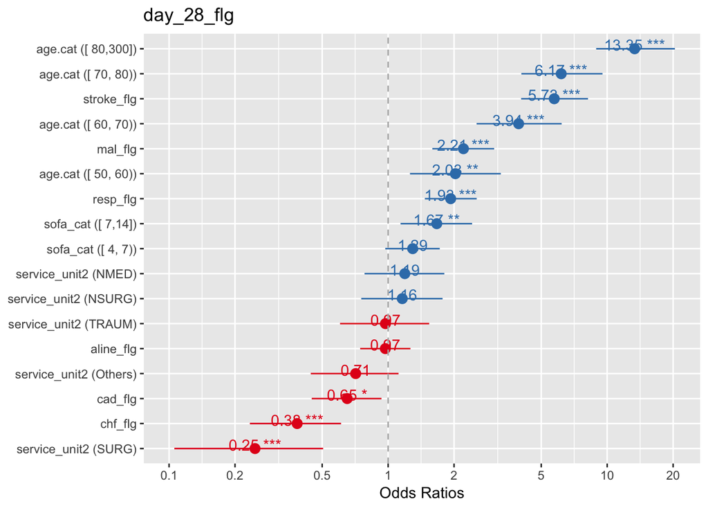

```r
sjp.glm(fit9.glm)
```

> 3. There are many other ways to do model selection, including automated procedures. We would *not* encourage you to use these automated methods as a first line of model selection, but can be useful for seeing if your result is robust to alternative procedures. One such way to do this is to specifying a full model, and then perform model selection based on some pre-defined criteria. For example, if `full.model` is your model with all variables in it, `stepAIC` in the `MASS` package will perform stepwise selection based on the Akaike Information Criteria. Fit a model with all variables we considered in the forward selection (the ‘full model’). Run `stepAIC` on this model with a `scope=list(lower=~aline_flg)` argument.

```r
library(MASS)
```

```r
full.model=glm(day_28_flg ~ aline_flg +  + age.cat + sofa_cat + service_unit2 + renal_flg + chf_flg + cad_flg + stroke_flg + mal_flg + resp_flg, data = dat,family = "binomial")
full.model.setpAIC<-stepAIC(full.model, scope=list(lower=~aline_flg))
```

```
## Start:  AIC=1775.17
## day_28_flg ~ aline_flg + +age.cat + sofa_cat + service_unit2 +
##     renal_flg + chf_flg + cad_flg + stroke_flg + mal_flg + resp_flg
##
##                 Df Deviance    AIC
## - renal_flg      1   1737.2 1773.2
## <none>               1737.2 1775.2
## - cad_flg        1   1742.7 1778.7
## - sofa_cat       2   1745.5 1779.5
## - service_unit2  5   1759.0 1787.0
## - chf_flg        1   1754.5 1790.5
## - mal_flg        1   1759.1 1795.1
## - resp_flg       1   1759.7 1795.7
## - stroke_flg     1   1837.9 1873.9
## - age.cat        4   1941.6 1971.6
##
## Step:  AIC=1773.19
## day_28_flg ~ aline_flg + age.cat + sofa_cat + service_unit2 +
##     chf_flg + cad_flg + stroke_flg + mal_flg + resp_flg
##
##                 Df Deviance    AIC
## <none>               1737.2 1773.2
## - cad_flg        1   1742.7 1776.7
## - sofa_cat       2   1745.5 1777.5
## - service_unit2  5   1759.0 1785.0
## - chf_flg        1   1754.8 1788.8
## - mal_flg        1   1759.1 1793.1
## - resp_flg       1   1759.8 1793.8
## - stroke_flg     1   1838.0 1872.0
## - age.cat        4   1942.8 1970.8
```

```r
summary(full.model.setpAIC)
```

```
##
## Call:
## glm(formula = day_28_flg ~ aline_flg + age.cat + sofa_cat + service_unit2 +
##     chf_flg + cad_flg + stroke_flg + mal_flg + resp_flg, family = "binomial",
##     data = dat)
##
## Deviance Residuals:
##     Min       1Q   Median       3Q      Max
## -1.9020  -0.5025  -0.2909  -0.2046   2.9411
##
## Coefficients:
##                     Estimate Std. Error z value Pr(>|z|)
## (Intercept)         -3.79877    0.22095 -17.193  < 2e-16 ***
## aline_flg           -0.02914    0.13464  -0.216 0.828675
## age.cat[ 50, 60)     0.70676    0.24280   2.911 0.003604 **
## age.cat[ 60, 70)     1.37180    0.22757   6.028 1.66e-09 ***
## age.cat[ 70, 80)     1.81940    0.21714   8.379  < 2e-16 ***
## age.cat[ 80,300]     2.59117    0.21076  12.294  < 2e-16 ***
## sofa_cat[ 4, 7)      0.25822    0.14597   1.769 0.076896 .
## sofa_cat[ 7,14]      0.51130    0.19159   2.669 0.007614 **
## service_unit2NMED    0.17545    0.21374   0.821 0.411747
## service_unit2NSURG   0.14880    0.21786   0.683 0.494606
## service_unit2Others -0.34097    0.23484  -1.452 0.146516
## service_unit2SURG   -1.39935    0.39418  -3.550 0.000385 ***
## service_unit2TRAUM  -0.02786    0.23848  -0.117 0.907002
## chf_flg             -0.95620    0.24371  -3.924 8.73e-05 ***
## cad_flg             -0.43043    0.18676  -2.305 0.021184 *
## stroke_flg           1.74619    0.17916   9.747  < 2e-16 ***
## mal_flg              0.79157    0.16573   4.776 1.79e-06 ***
## resp_flg             0.65748    0.13893   4.733 2.22e-06 ***
## ---
## Signif. codes:  0 '***' 0.001 '**' 0.01 '*' 0.05 '.' 0.1 ' ' 1
##
## (Dispersion parameter for binomial family taken to be 1)
##
##     Null deviance: 2340.8  on 2750  degrees of freedom
## Residual deviance: 1737.2  on 2733  degrees of freedom
## AIC: 1773.2
##
## Number of Fisher Scoring iterations: 6
```

> 4. Another criteria is the BIC (or Bayesian Information Criteria). Repeat step c), but add an additional argument: `k=log(n)`, where `n` needs to be the number of rows in the dataset. How does this model compare with your parts a) and c)? Does this conform with what is known about AIC and BIC?

```r
nrow(dat)
```

```
## [1] 2751
```

```r
full.model.setpBIC<-stepAIC(full.model, scope=list(lower=~aline_flg),k=log(2751))
```

```
## Start:  AIC=1887.65
## day_28_flg ~ aline_flg + +age.cat + sofa_cat + service_unit2 +
##     renal_flg + chf_flg + cad_flg + stroke_flg + mal_flg + resp_flg
##
##                 Df Deviance    AIC
## - service_unit2  5   1759.0 1869.9
## - renal_flg      1   1737.2 1879.8
## - sofa_cat       2   1745.5 1880.1
## - cad_flg        1   1742.7 1885.2
## <none>               1737.2 1887.7
## - chf_flg        1   1754.5 1897.0
## - mal_flg        1   1759.1 1901.7
## - resp_flg       1   1759.7 1902.3
## - stroke_flg     1   1837.9 1980.5
## - age.cat        4   1941.6 2060.4
##
## Step:  AIC=1869.9
## day_28_flg ~ aline_flg + age.cat + sofa_cat + renal_flg + chf_flg +
##     cad_flg + stroke_flg + mal_flg + resp_flg
##
##              Df Deviance    AIC
## - sofa_cat    2   1766.4 1861.5
## - renal_flg   1   1759.0 1862.0
## - cad_flg     1   1766.4 1869.4
## <none>            1759.0 1869.9
## - mal_flg     1   1775.8 1878.8
## - chf_flg     1   1776.4 1879.3
## - resp_flg    1   1787.1 1890.0
## - age.cat     4   1970.7 2049.9
## - stroke_flg  1   1959.5 2062.5
##
## Step:  AIC=1861.46
## day_28_flg ~ aline_flg + age.cat + renal_flg + chf_flg + cad_flg +
##     stroke_flg + mal_flg + resp_flg
##
##              Df Deviance    AIC
## - renal_flg   1   1766.5 1853.6
## - cad_flg     1   1774.2 1861.3
## <none>            1766.4 1861.5
## - mal_flg     1   1785.0 1872.1
```

[output cut: 14 more lines]

```
## - resp_flg    1   1797.0 1876.2
## - age.cat     4   1983.8 2039.2
## - stroke_flg  1   1964.8 2044.0
##
## Step:  AIC=1853.42
## day_28_flg ~ aline_flg + age.cat + chf_flg + stroke_flg + mal_flg +
##     resp_flg
##
##              Df Deviance    AIC
## <none>            1774.2 1853.4
## - mal_flg     1   1794.4 1865.7
## - chf_flg     1   1798.5 1869.8
## - resp_flg    1   1806.6 1877.9
## - age.cat     4   1983.8 2031.3
## - stroke_flg  1   1974.6 2045.9
```

```r
summary(full.model.setpBIC)
```

```
##
## Call:
## glm(formula = day_28_flg ~ aline_flg + age.cat + chf_flg + stroke_flg +
##     mal_flg + resp_flg, family = "binomial", data = dat)
##
## Deviance Residuals:
##     Min       1Q   Median       3Q      Max
## -1.8395  -0.5337  -0.2965  -0.2038   2.8990
##
## Coefficients:
##                  Estimate Std. Error z value Pr(>|z|)
## (Intercept)       -3.7383     0.1940 -19.267  < 2e-16 ***
## aline_flg         -0.1257     0.1246  -1.008  0.31332
## age.cat[ 50, 60)   0.6355     0.2395   2.654  0.00796 **
## age.cat[ 60, 70)   1.2938     0.2214   5.844 5.10e-09 ***
## age.cat[ 70, 80)   1.6986     0.2097   8.098 5.57e-16 ***
## age.cat[ 80,300]   2.5066     0.2033  12.327  < 2e-16 ***
## chf_flg           -1.0843     0.2396  -4.526 6.02e-06 ***
## stroke_flg         1.9869     0.1420  13.990  < 2e-16 ***
## mal_flg            0.7289     0.1583   4.604 4.15e-06 ***
## resp_flg           0.7331     0.1291   5.678 1.36e-08 ***
## ---
## Signif. codes:  0 '***' 0.001 '**' 0.01 '*' 0.05 '.' 0.1 ' ' 1
##
## (Dispersion parameter for binomial family taken to be 1)
##
##     Null deviance: 2340.8  on 2750  degrees of freedom
## Residual deviance: 1774.2  on 2741  degrees of freedom
## AIC: 1794.2
##
## Number of Fisher Scoring iterations: 6
```

### potential confounders:

1. age (<50, 50-60, 60-70,70-80, >80)
2. sofa (0-4, 4-6, >7)
3. service_unit (as defined earlier in this workshop for `service_unit2`)
4. Binary co-morbidities: `renal_flg`, `chf_flg`, `cad_flg`, `stroke_flg`, `mal_flg`, `resp_flg`.

### Step wise,forward

day_28_flg ~ aline_flg + age.cat + sofa_cat + service_unit2 + chf_flg + cad_flg + stroke_flg + mal_flg + resp_flg `renal_flg` ###AIC day_28_flg ~ aline_flg + age.cat + sofa_cat + service_unit2 + chf_flg + cad_flg + stroke_flg + mal_flg + resp_flg `renal_flg` ###BIC day_28_flg ~ aline_flg + age.cat + chf_flg + stroke_flg + mal_flg + resp_flg `renal_flg` `sofa_cat` `service_unit2` `cad_flg`

### to compare the perfomance of model, I will do anova

```r
anova(fit9.glm,full.model.setpAIC,test = "Chisq")
```

```
## Analysis of Deviance Table
##
## Model 1: day_28_flg ~ aline_flg + age.cat + service_unit2 + stroke_flg +
##     mal_flg + resp_flg + chf_flg + sofa_cat + cad_flg
## Model 2: day_28_flg ~ aline_flg + age.cat + sofa_cat + service_unit2 +
##     chf_flg + cad_flg + stroke_flg + mal_flg + resp_flg
##   Resid. Df Resid. Dev Df Deviance Pr(>Chi)
## 1      2733     1737.2
## 2      2733     1737.2  0        0
```

```r
anova(fit9.glm,full.model.setpBIC,test = "Chisq")
```

```
## Analysis of Deviance Table
##
## Model 1: day_28_flg ~ aline_flg + age.cat + service_unit2 + stroke_flg +
##     mal_flg + resp_flg + chf_flg + sofa_cat + cad_flg
## Model 2: day_28_flg ~ aline_flg + age.cat + chf_flg + stroke_flg + mal_flg +
##     resp_flg
##   Resid. Df Resid. Dev Df Deviance  Pr(>Chi)
## 1      2733     1737.2
## 2      2741     1774.2 -8  -37.036 1.134e-05 ***
## ---
## Signif. codes:  0 '***' 0.001 '**' 0.01 '*' 0.05 '.' 0.1 ' ' 1
```

```r
anova(full.model.setpBIC,full.model.setpAIC,test = "Chisq")
```

```
## Analysis of Deviance Table
##
## Model 1: day_28_flg ~ aline_flg + age.cat + chf_flg + stroke_flg + mal_flg +
##     resp_flg
## Model 2: day_28_flg ~ aline_flg + age.cat + sofa_cat + service_unit2 +
##     chf_flg + cad_flg + stroke_flg + mal_flg + resp_flg
##   Resid. Df Resid. Dev Df Deviance  Pr(>Chi)
## 1      2741     1774.2
## 2      2733     1737.2  8   37.036 1.134e-05 ***
## ---
## Signif. codes:  0 '***' 0.001 '**' 0.01 '*' 0.05 '.' 0.1 ' ' 1
```

### From the result of anova(partial F test),the step wise model and AIC model have the same performance as the prediction model. The same ability to predict the 28 days mortality.

### The setp wise model, as well AIC model, has significant diffrenct ability to predict the hospital mortality from the BIC model. Howeverm I have no ideat to tell tell which is a better model.

> 5. Which model would you choose as the model you would present? Why? What other criteria would you like to use? (don’t do these) Does it make a difference from drawing any conclusions from the main study objective?

### sorry, I have no knowledge to adress this question.